# L206

- **出席を確認する。**
- **演習では，他人のデバイスに触らない．自分のデバイスを，他人に触らせない．**

**新しいノートブックは作らない．**前回作業したノートブックは，Google Driveの「マイドライブ/Colab Notebooks」に保存されているはず．それを開いて再開する．

## 1 オブジェクト指向プログラミングの4大要素（教科書第13章）

### 1.1 カプセル化

**課題** 5個の数値からなるリスト`_nums = [1, 2, 3, 4, 5]`を保持するクラス`Data`を作れ。数値は，番号を指定して変更できるようにせよ。使用例を示す。

```python
# 実行例1
data1 = Data()
data1.change_data(0, 100)
data1.change_data(3, -300)
print(data1._nums)
```

```
[100, 2, 3, -300, 5]
```

Pythonらしい書き方をするなら，`change_data()`の代わりに特殊メソッド`__setitem__()`を実装するのだが，ここでの目的はプログラミングについて学ぶことだからこのままでよい。（後で特殊メソッドを使う課題がある。）

**課題** 次のように，インスタンス変数`_nums`を直接変更できることを確かめよ。

```python
# 実行例2
data2 = Data()
data2._nums[0] = 100
data2._nums[3] = -300
print(data2._nums)
```

```
[100, 2, 3, -300, 5]
```

クラス`Date`を説明するためのUMLクラス図を描く。ここでは，テキストからUMLダイアグラムを生成する，PlantUMLを使う。

PythonでPlantUMLを使うためのパッケージをインストールする。

```bash
pip install plantuml | tail -n 1
```

クラス図を描く。

```python
from IPython.display import Image, display
from plantuml import PlantUML

plantuml_code = """
@startuml
skinparam classAttributeIconSize 0

class Data {
  - _nums
  - __init__()
  + change_data(index, n)
}
@enduml
"""

puml = PlantUML("http://www.plantuml.com/plantuml/png/")
png = puml.processes(plantuml_code)
Image(png)
```

[output not shown]

クラスとインスタンスの関係を可視化する。

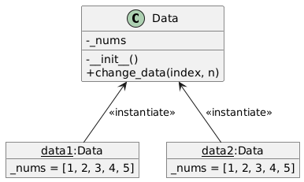

### 1.2 抽象化

ここに課題はない。

### 1.3 ポリモーフィズム

**課題** 次のコードと実行結果に合うような，クラス`Triangle`，`Square`，`Circle`を実装せよ。

```python
tr1 = Triangle()
sq1 = Square()
cr1 = Circle()

shapes = [tr1, sq1, cr1]
for a_shape in shapes:
  if isinstance(a_shape, Triangle):
    a_shape.draw_triangle()
  if isinstance(a_shape, Square):
    a_shape.draw_square()
  if isinstance(a_shape, Circle):
    a_shape.draw_circle()
```

```
△
□
○
```

**課題** 次のコードと実行結果に合うように，クラス`Triangle`，`Square`，`Circle`を修正せよ。

```python
tr1 = Triangle()
sq1 = Square()
cr1 = Circle()

shapes = [tr1, sq1, cr1]
for a_shape in shapes:
  a_shape.draw()
```

```
△
□
○
```

横300px，縦200pxのキャンバスに長方形を描く例を示す。画像の描き方・座標軸を確認せよ。参照：https://pillow.readthedocs.io/en/stable/reference/ImageDraw.html#PIL.ImageDraw.ImageDraw.rectangle

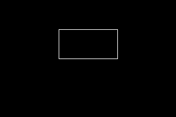

```python
from PIL import Image, ImageDraw

size = (300, 200)

topleft     = (100, 50)
bottomright = (200, 100)

im = Image.new("RGB", size)
draw = ImageDraw.Draw(im)
draw.rectangle((topleft, bottomright))
im
```

**課題** 次のコードと実行結果に合うような，クラス`Circle`を実装せよ。ヒント：https://pillow.readthedocs.io/en/stable/reference/ImageDraw.html#PIL.ImageDraw.ImageDraw.circle

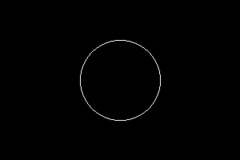

```python
circle1 = Circle(50)
circle1.draw()
```

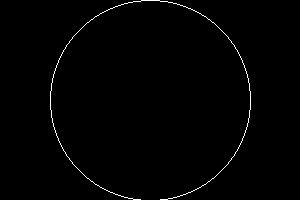

```python
circle2 = Circle(100)
circle2.draw()
```

**課題** 次のコードと実行結果に合うような，クラス`Rectangle`を実装せよ。

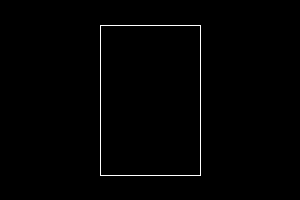

```python
rectamgle1 = Rectangle(100, 150)
rectamgle1.draw()
```

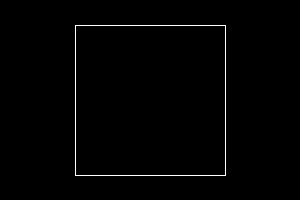

```python
rectamgle2 = Rectangle(150, 150)
rectamgle2.draw()
```

**課題♠** 次のコードと実行結果に合うような，クラス`Triangle`を実装せよ。キャンバス中の位置や向きをこのとおりにする必要はない。ヒント：辺の長さ→（余弦定理）→角度→座標→polygon

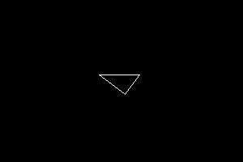

```python
triangle1 = Triangle(30, 40, 50)
triangle1.draw()
```

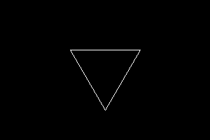

```python
triangle2 = Triangle(100, 100, 100)
triangle2.draw()
```

### 1.4 特殊メソッド

先に作成したクラス`Data`を，次のように変更せよ。

- `len(インスタンス)`で要素数を得る。
- メソッド`change_data()`ではなく，`[]`で要素を更新する。
- 要素に負の値を設定しようとすると，その絶対値が設定される。
- `print(インスタンス)`で要素を表示する。
- インスタンスを評価すると，文字列`Data()`が返る。

使用例を示す。

```python
data = Data()
print(len(data))
data[0] = 100
data[3] = -300
print(data)
data
```

```
5
[100, 2, 3, 300, 5]
Data()
```

### 1.5 継承

**課題** インスタンスが名前`_name`と年齢`_age`を保持するクラス`Person`を実装せよ。使用例を示す。

```python
p = Person("Taro", 40)
print(p)
```

```
Taro (40)
```

**課題** クラス`Person`を継承するクラス`Student`を実装せよ。使用例を示す。

```python
s = Student("Hanako", 22, 123)
print(s)
s.study()
```

```
Hanako (22)
Hanako (22) id=123: studying...
```

クラス`Person`とクラス`Student`の関係をクラス図で表す。

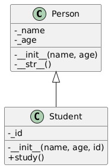

**課題** クラス`Student`でメソッド`__str__()`をオーバーライドして，`print(インスタンス)`で`_id`を表示するようにせよ。実行例を示す。

```python
p = Person("Taro", 40)
print(p)

s = Student("Hanako", 22, 123)
print(s)
s.study()
```

```
Taro (40)
Hanako (22) id=123
Hanako (22) id=123: studying...
```

### 1.6 コンポジション

**課題** インスタンスが飼い主を保持するクラス`Dog`を実装せよ。使用例を示す。

```python
mick = Person("Mick Jagger", 80)
stan = Dog("Stanley", "Bulldog", mick)
print(stan._owner._name)
```

```
Mick Jagger
```

**課題** `Person`，`Student`，`Dog`の関係をUMLクラス図で表せ。

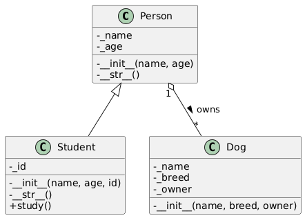

## 2 もっとオブジェクト指向プログラミング（教科書第14章）

### 2.1 クラス変数 vs インスタンス変数

**課題** クラス`Person`に，インスタンスの`_name`を記録するためのクラス変数`people`を追加せよ。使用例を示す。

```python
p1 = Person("Taro", 40)
p2 = Person("Hanako", 22)
print(Person.people)
```

```
['Taro', 'Hanako']
```

### 2.2 有理数

$r_1:=\dfrac{1}{3}$, $r_2:=\dfrac{3}{9}$とする。$r_1+r_2$を，SymPyを使って求める。

```python
from sympy import Rational

r1 = Rational(1, 3)
r2 = Rational(3, 9)
r3 = r1 + r2
print(r1)
print(r2)
print(r3)
```

```
1/3
1/3
2/3
```

**課題** 有理数を表すクラス`Ratio`を，SymPyを使わずに実装せよ。使用例を示す。

```python
r1 = Ratio(1, 3)
r2 = Ratio(3, 9)
print(r1)
print(r2)
```

```
1/3
3/9
```

**課題** 二つの正の整数の最大公約数を求める関数`gcd()`を実装せよ。確認する例を示す。（最大公約数を求める有名なアルゴリズムがあるが，ここでは単純な実装でよい。）

```python
assert gcd(10, 15) == 5
assert gcd(10, 20) == 10
assert gcd(20, 10) == 10
```

**課題** 既約になるようにせよ。使用例を示す。

```python
r1 = Ratio(1, 3)
r2 = Ratio(3, 9)
print(r1)
print(r2)
```

```
1/3
1/3
```

**課題** 加算ができるようにせよ。使用例を示す。対象が`Ratio`のインスタンスでない場合については考慮しなくてよい。

```python
r1 = Ratio(1, 3)
r2 = Ratio(3, 9)
r3 = r1 + r2
print(r3)
```

```
2/3
```

**課題** 等号が適切になるようせよ。使用例を示す。対象が`Ratio`のインスタンスでない場合については考慮しなくてよい。

```python
r1 = Ratio(1, 3)
r2 = Ratio(3, 9)
print(r1 == r2)
```

```
True
```

### 2.3 is

**課題** `r1`と`r2`は同一のオブジェクトではないことを確認せよ。

## 3 補足

教科書の次の2章は，「独学」しておくことを勧める。

- 第10章 知識を1つにまとめる
- 第15章 知識を1つにまとめる

**課題** これまでの課題について，気になったことを新たな**課題**とし，調べて解決せよ。良い課題は，来年の演習で採用する（作問者名掲載）。

**課題** （時間に余裕がある場合）生成AIで全てをやり直せ。

## 4 宿題

1. 次のサービスのアカウントを作っておく．
- https://ja.overleaf.com/
- https://cloudlatex.io/ja
2. 数学の教科書の本文（まえがき・あとがき・目次・索引・文献リスト等以外）の1ページの写真を撮ってくる。教科書を持ってきてもよい。（$\mathrm{\LaTeX}$の練習に使う。）